# RQ2 Step 1: A profile of each district’s building market

What kinds of building markets does New Zealand have?

while True: learn(), Group 8, STAT462

2026-11-20

```r
source(file.path(proj_root, "R", "utils_data.R"))
source(file.path(proj_root, "R", "utils_cluster.R"))
library(knitr)

# ---- Settings for this notebook -------------------------------------------
WINDOW_FROM <- c(2016L, 3L)   # profile window: the last ten years, 2016Q3 to 2026Q2
SPLIT_AT    <- c(2021L, 3L)   # growth = second five years vs first five years
VOL_YEARS   <- 2006:2025      # volatility: twenty complete years (covers 2008-11 and the 2021 boom)

full <- read_csv(file.path(paths$processed, "rq1_district_quarter_full.csv"), show_col_types = FALSE)
dim(full)
```

```
## [1] 9715   43
```

# 1 Purpose

**Research question 2:** *What kinds of building markets does New Zealand have?*

RQ1 modelled one row per district and quarter. RQ2 is **unsupervised**: there is no response to predict. We describe each district by a handful of features and let a clustering method group districts that look alike. The pitch named four themes: **type mix, growth, volatility and cost**.

This notebook builds one row per district, checks the features, decides how to transform them, and checks how much they overlap. The clustering itself is in Step 2.

The input is the district-quarter table from RQ1 Step 1 (`rq1_district_quarter_full.csv`). It holds all 67 districts and every quarter from 1990Q2 to 2026Q2, so no raw data is needed.

# 2 Unit and time window

**One row per district.** Clustering 9,715 district-quarters would group *quarters*, mixing the same district across different times. RQ2 asks about *markets*, so each district gets one profile.

**Window: the last ten years, 2016Q3 to 2026Q2.** Ten years is long enough to smooth out the noise of small districts, and recent enough to describe today’s markets rather than those of the 1990s. Two features need a different period:

- **growth** compares the second five years with the first five years of the window;
- **volatility** uses twenty complete years (2006–2025), so that every district has been through a full cycle: the 2008–2011 downturn and the 2021 boom.

```r
from_index  <- yq_index(WINDOW_FROM[1], WINDOW_FROM[2])
split_index <- yq_index(SPLIT_AT[1], SPLIT_AT[2])
win <- full |> filter(t_index >= from_index)
c(first = min(win$yq), last = max(win$yq), quarters = n_distinct(win$yq))
```

```
##    first     last quarters
## "2016Q3" "2026Q2"     "40"
```

```r
win |> group_by(ta) |> summarise(new_dwellings = sum(dwell_n), new_houses = sum(houses_n)) |>
  arrange(new_dwellings) |> head(5) |> kable(caption = "Smallest districts over the window")
```

Smallest districts over the window

| ta | new_dwellings | new_houses |
| --- | --- | --- |
| Chatham Islands Territory | 34 | 32 |
| Kawerau District | 92 | 52 |
| Wairoa District | 167 | 132 |
| Waitomo District | 226 | 178 |
| Waimate District | 237 | 226 |

**Decision.** The Chatham Islands consented only 34 new dwellings in ten years. Shares and growth rates from so few dwellings are mostly noise, and its building market (an island 800 km offshore) is unlike any other. We leave it out, which gives **66 districts**. Kawerau (92 dwellings) is small but kept; we keep an eye on it.

```r
win  <- win  |> filter(ta != "Chatham Islands Territory")
full <- full |> filter(ta != "Chatham Islands Territory")
```

# 3 The features

Each feature answers a question about a district’s market. All money is in real June-2026 dollars, as in RQ1.

| Theme | Feature | Definition (over the window) | Question it answers |
| --- | --- | --- | --- |
| Type mix | `apt_share` | apartments ÷ new dwellings | Is it an apartment market? |
|  | `retire_share` | retirement-village units ÷ new dwellings | Is it a retirement market? |
|  | `town_share` | townhouses, flats and units ÷ new dwellings | Is it a medium-density market? |
|  | `house_share` | stand-alone houses ÷ new dwellings | (the remainder; see the VIF section) |
| Intensity | `dwell_per_1000` | average new dwellings per 1,000 residents per year | How fast is it building for its size? |
| Growth | `growth` | log(new dwellings in the second five years ÷ first five years) | Is building speeding up or slowing down? |
| Volatility | `volatility` | standard deviation of the yearly log change in new dwellings, 2006–2025 | Does it boom and bust? |
| Cost | `rel_cost` | log(district real $/m² ÷ real $/m² of all other districts) | Is it dear or cheap to build in? |
| House size | `house_m2` | floor area ÷ number of new houses | Does it build big houses? |
| Economy | `nonres_share` | new non-residential value ÷ (new non-residential + new residential value) | Is building mostly homes, or also commercial? |
| Renovation | `alt_share` | residential alterations ÷ (alterations + new residential) | Is it a mature market that renovates more than it builds? |

**Size is left out on purpose.** The number of new dwellings would dominate any clustering (Auckland builds 50 times more than most districts), and the result would be a ranking by size. We want districts of different sizes to fall in the same group if their markets *work* the same way. Intensity (`dwell_per_1000`) measures activity relative to population instead. Size is still used afterwards, to describe the clusters.

Every share and ratio is computed from **totals over the window** (for example, total apartments ÷ total dwellings), not as an average of quarterly ratios, so quarters with few dwellings don’t count as much as busy ones.

```r
# national totals, used for the leave-one-out cost comparison
nat <- win |> summarise(val = sum(houses_val * real_factor), m2 = sum(houses_m2))

feat <- win |>
  group_by(ta, region, island, is_city) |>
  summarise(
    dwellings      = sum(dwell_n),
    houses         = sum(houses_n),
    apt_share      = sum(apt_n) / sum(dwell_n),
    retire_share   = sum(retire_n) / sum(dwell_n),
    town_share     = sum(town_n) / sum(dwell_n),
    house_share    = sum(houses_n) / sum(dwell_n),
    dwell_per_1000 = mean(dwell_per_1000),
    growth         = log((sum(dwell_n[t_index >= split_index]) + 1) / (sum(dwell_n[t_index < split_index]) + 1)),
    rel_cost       = log(sum(houses_val * real_factor) / sum(houses_m2)) -
                     log((nat$val - sum(houses_val * real_factor)) / (nat$m2 - sum(houses_m2))),
    house_m2       = sum(houses_m2) / sum(houses_n),
    nonres_share   = sum(nonres_new_val) / (sum(nonres_new_val) + sum(resid_new_val)),
    alt_share      = sum(resid_alt_val) / (sum(resid_alt_val) + sum(resid_new_val)),
    .groups = "drop")

# volatility from yearly totals: quarterly counts in small districts are too noisy
volatility <- full |>
  filter(year %in% VOL_YEARS) |>
  group_by(ta, year) |>
  summarise(dwellings = sum(dwell_n), .groups = "drop") |>
  group_by(ta) |>
  summarise(volatility = sd(diff(log(dwellings + 1))), years = n())
stopifnot(all(volatility$years == length(VOL_YEARS)))

feat <- feat |> left_join(volatility |> select(ta, volatility), by = "ta")
c(districts = nrow(feat), missing_values = sum(is.na(feat)))
```

```
##      districts missing_values
##             66              0
```

**Observation.** 66 districts, no missing values. The `+ 1` in growth and volatility avoids log(0) when a district consents no dwellings in a year. It only matters for the smallest districts.

# 4 Checking the features

```r
all_vars <- c("apt_share", "retire_share", "town_share", "house_share", "dwell_per_1000", "growth",
              "volatility", "rel_cost", "house_m2", "nonres_share", "alt_share")

feat_summary <- feat |>
  select(all_of(all_vars)) |>
  pivot_longer(everything(), names_to = "feature") |>
  group_by(feature) |>
  summarise(min = min(value), median = median(value), max = max(value),
            skewness = mean((value - mean(value))^3) / sd(value)^3, .groups = "drop") |>
  arrange(desc(abs(skewness)))
feat_summary |> kable(digits = 3, caption = "Features before any transformation (66 districts)")
```

Features before any transformation (66 districts)

| feature | min | median | max | skewness |
| --- | --- | --- | --- | --- |
| apt_share | 0.000 | 0.005 | 0.389 | 4.804 |
| volatility | 0.181 | 0.302 | 1.001 | 2.948 |
| dwell_per_1000 | 1.225 | 5.010 | 27.515 | 2.507 |
| town_share | 0.027 | 0.124 | 0.558 | 1.452 |
| house_share | 0.259 | 0.820 | 0.954 | -1.277 |
| house_m2 | 129.912 | 184.406 | 208.632 | -1.018 |
| retire_share | 0.000 | 0.040 | 0.194 | 0.990 |
| rel_cost | -0.180 | -0.047 | 0.303 | 0.814 |
| nonres_share | 0.074 | 0.271 | 0.703 | 0.746 |
| growth | -0.602 | 0.035 | 0.888 | 0.448 |
| alt_share | 0.033 | 0.173 | 0.331 | 0.262 |

```r
# the extreme districts on the most skewed features
bind_rows(feat |> slice_max(apt_share, n = 3) |> mutate(feature = "apt_share"),
          feat |> slice_max(dwell_per_1000, n = 3) |> mutate(feature = "dwell_per_1000"),
          feat |> slice_max(volatility, n = 3) |> mutate(feature = "volatility")) |>
  select(feature, ta, apt_share, dwell_per_1000, volatility) |>
  kable(digits = 3)
```

| feature | ta | apt_share | dwell_per_1000 | volatility |
| --- | --- | --- | --- | --- |
| apt_share | Wellington City | 0.389 | 4.188 | 0.321 |
| apt_share | Auckland | 0.151 | 8.943 | 0.187 |
| apt_share | Nelson City | 0.109 | 4.898 | 0.316 |
| dwell_per_1000 | Queenstown-Lakes District | 0.081 | 27.515 | 0.214 |
| dwell_per_1000 | Selwyn District | 0.002 | 20.455 | 0.255 |
| dwell_per_1000 | Mackenzie District | 0.004 | 18.578 | 0.270 |
| volatility | Kawerau District | 0.011 | 1.225 | 1.001 |
| volatility | Waitomo District | 0.013 | 2.297 | 0.729 |
| volatility | Wairoa District | 0.000 | 1.758 | 0.551 |

**Observation.** Several features are strongly **right-skewed** (skewness well above 1): a few districts have values far above the rest. Wellington City builds 39% apartments when the median district builds 0.5%. Queenstown and Selwyn build far more dwellings per resident than anywhere else. Kawerau’s volatility is extreme because a few dwellings more or less make a large percentage change.

This matters for clustering. Distance-based methods (k-means, hierarchical) measure how far apart districts are. One district far out on a single feature is then far from *everything*, and ends up in a cluster of its own. In a first trial without transformation, Wellington City formed a one-district cluster purely because of its apartment share. That says nothing about kinds of markets.

## 4.1 Transformations

We transform the skewed features so that their extreme values are pulled in, while keeping the order of the districts:

- **square root** for the shares (`apt_share`, `retire_share`, `town_share`, `nonres_share`). The square root works for values of exactly 0, which a log does not, and it spreads out the small shares where most districts are;
- **log** for `dwell_per_1000` and `volatility`, which are positive rates.

`growth` and `rel_cost` are already logs of ratios, and `house_m2` is only mildly skewed with no extreme values, so they are left as they are.

```r
tf <- feat |>
  mutate(across(c(apt_share, retire_share, town_share, nonres_share, house_share, alt_share), sqrt),
         dwell_per_1000 = log(dwell_per_1000),
         volatility     = log(volatility))

skew <- function(x) mean((x - mean(x))^3) / sd(x)^3
skew_compare <- tibble(feature = all_vars,
                       before = map_dbl(all_vars, \(v) skew(feat[[v]])),
                       after  = map_dbl(all_vars, \(v) skew(tf[[v]])))
kable(skew_compare, digits = 2, caption = "Skewness before and after transforming")
```

Skewness before and after transforming

| feature | before | after |
| --- | --- | --- |
| apt_share | 4.80 | 1.93 |
| retire_share | 0.99 | -0.05 |
| town_share | 1.45 | 0.84 |
| house_share | -1.28 | -1.56 |
| dwell_per_1000 | 2.51 | 0.26 |
| growth | 0.45 | 0.45 |
| volatility | 2.95 | 1.11 |
| rel_cost | 0.81 | 0.81 |
| house_m2 | -1.02 | -1.02 |
| nonres_share | 0.75 | 0.06 |
| alt_share | 0.26 | -0.22 |

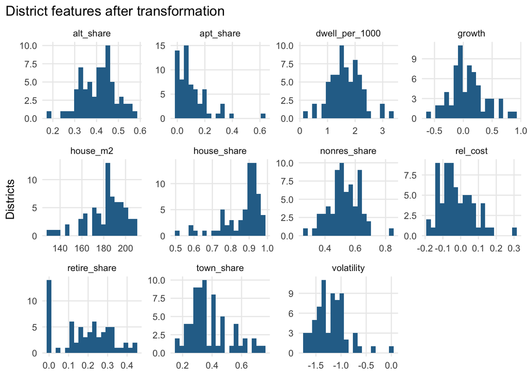

```r
p_dist <- tf |>
  select(all_of(all_vars)) |>
  pivot_longer(everything(), names_to = "feature") |>
  ggplot(aes(value)) +
  geom_histogram(bins = 20, fill = "#2a6f97") +
  facet_wrap(~feature, scales = "free", ncol = 4) +
  labs(title = "District features after transformation", x = NULL, y = "Districts")
save_fig(p_dist, "fig01_feature_distributions", dir = paths$fig_rq2, height = 5, width = 8)
```

## 4.2 Standardising

# 5 Do the features overlap? (correlation and VIF)

In clustering, two features that measure the same thing count that thing **twice** in the distance. So we check for overlap before clustering.

## 5.1 Correlation

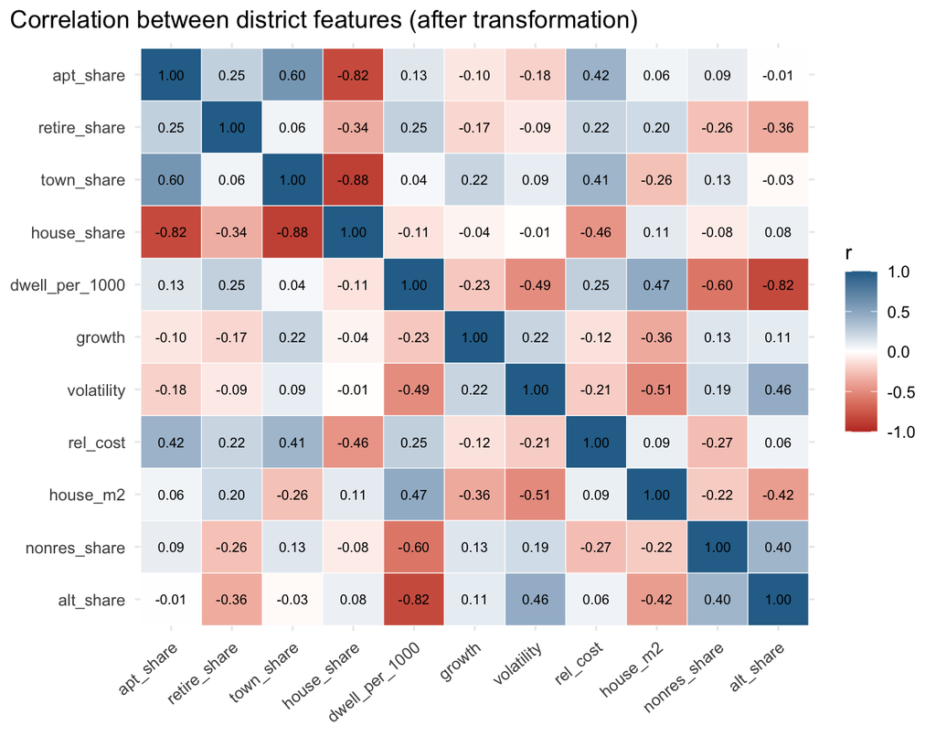

```r
cm <- cor(tf |> select(all_of(all_vars)))
p_cor <- as_tibble(cm, rownames = "a") |>
  pivot_longer(-a, names_to = "b", values_to = "r") |>
  mutate(a = factor(a, levels = all_vars), b = factor(b, levels = rev(all_vars))) |>
  ggplot(aes(a, b, fill = r)) +
  geom_tile(colour = "white") +
  geom_text(aes(label = sprintf("%.2f", r)), size = 2.6) +
  scale_fill_gradient2(low = "#c0392b", mid = "white", high = "#2a6f97", limits = c(-1, 1)) +
  labs(title = "Correlation between district features (after transformation)", x = NULL, y = NULL, fill = "r") +
  theme(axis.text.x = element_text(angle = 40, hjust = 1))
save_fig(p_cor, "fig02_feature_correlation", dir = paths$fig_rq2, height = 5.5)
```

## 5.2 Variance inflation factor (VIF)

A correlation only compares two features at a time. The **variance inflation factor** asks whether a feature can be predicted from *all* the others together:

$$\text{VIF}_j = \frac{1}{1 - R^2_j}$$

where $R^2_j$ is the R² from regressing feature *j* on every other feature. A VIF of 1 means the feature is unrelated to the others. A VIF of 5 means 80% of its variation is already in the others ($R^2_j$ = 0.8). The usual warning level is 5, and above 10 is a clear problem. The name comes from regression, where it is the factor by which overlap inflates the variance of a coefficient. Here we use it as a measure of redundancy.

```r
vif_table(tf |> select(all_of(all_vars))) |> arrange(desc(vif)) |>
  kable(digits = 2, caption = "VIF with all eleven features")
```

VIF with all eleven features

| feature | vif |
| --- | --- |
| house_share | 18.70 |
| town_share | 10.16 |
| dwell_per_1000 | 7.39 |
| alt_share | 7.17 |
| apt_share | 5.16 |
| retire_share | 2.64 |
| rel_cost | 2.48 |
| nonres_share | 2.02 |
| volatility | 1.91 |
| house_m2 | 1.75 |
| growth | 1.31 |

**Observation.** `house_share` has a VIF of about 19 and `town_share` about 10. Houses, apartments, retirement units and townhouses are the four kinds of new dwelling, so their shares add up to exactly 1, and any one of them is fully determined by the other three. On the original scale this is perfect **collinearity** and the VIF is infinite (below). The square root bends the relationship slightly, so after transforming it is “only” 19. We drop `house_share`: a low share of everything else already means a high share of houses.

```r
vif_table(feat |> select(house_share, apt_share, retire_share, town_share)) |>
  kable(digits = 2, caption = "VIF of the four shares on their original scale")
```

VIF of the four shares on their original scale

| feature | vif |
| --- | --- |
| house_share | Inf |
| apt_share | Inf |
| retire_share | Inf |
| town_share | Inf |

```r
vars_10 <- setdiff(all_vars, "house_share")
vif_table(tf |> select(all_of(vars_10))) |> arrange(desc(vif)) |>
  kable(digits = 2, caption = "VIF without house_share")
```

VIF without house_share

| feature | vif |
| --- | --- |
| dwell_per_1000 | 7.31 |
| alt_share | 7.14 |
| town_share | 2.75 |
| rel_cost | 2.48 |
| apt_share | 2.31 |
| nonres_share | 2.00 |
| volatility | 1.87 |
| retire_share | 1.75 |
| house_m2 | 1.74 |
| growth | 1.30 |

**Observation.** Without `house_share`, two features still have a VIF of about 7: `dwell_per_1000` and `alt_share`. They are the two ends of one idea. A district that builds a lot of new housing for its population (high intensity) has, almost by definition, a small share of its residential spending going to alterations. Keeping both would count “how much is being built” twice. We drop `alt_share` and keep `dwell_per_1000`, which is easier to interpret and does not depend on how alterations are valued.

```r
cluster_vars <- setdiff(vars_10, "alt_share")
vif_final <- vif_table(tf |> select(all_of(cluster_vars))) |> arrange(desc(vif))
save_tab(vif_final, "t01_vif", dir = paths$tab_rq2) |> kable(digits = 2, caption = "VIF of the nine clustering features")
```

VIF of the nine clustering features

| feature | vif |
| --- | --- |
| dwell_per_1000 | 2.41 |
| town_share | 2.32 |
| apt_share | 2.02 |
| nonres_share | 1.95 |
| house_m2 | 1.73 |
| volatility | 1.67 |
| rel_cost | 1.56 |
| growth | 1.29 |
| retire_share | 1.21 |

**Observation.** All nine features now have VIF below 2.5. They overlap a little (no two are unrelated), but none repeats the others, so each adds its own information to the distance.

## 5.3 Volatility and district size

```r
c(cor_volatility_log_size = cor(tf$volatility, log(tf$dwellings)))
```

```
## cor_volatility_log_size
##              -0.5950451
```

# 6 A first look at the structure: principal component analysis (PCA)

With nine features we can’t plot the districts directly. **Principal component analysis** finds new axes (principal components), each a weighted combination of the standardised features, chosen so that the first axis captures as much of the spread between districts as possible, the second as much of the rest as possible, and so on. The weights are called **loadings**. Plotting the first two components is the best two-dimensional picture of the nine-dimensional data. We use PCA only to *look* at the data; the clustering in Step 2 uses all nine features.

```r
X <- scale(tf |> select(all_of(cluster_vars)))
rownames(X) <- str_remove(tf$ta, " District| City")
pca <- prcomp(X)

pca_var <- tibble(component = paste0("PC", 1:9), variance_share = pca$sdev^2 / sum(pca$sdev^2),
                  cumulative = cumsum(variance_share))
kable(head(pca_var, 5), digits = 3, caption = "Share of the variance captured by each component")
```

Share of the variance captured by each component

| component | variance_share | cumulative |
| --- | --- | --- |
| PC1 | 0.305 | 0.305 |
| PC2 | 0.219 | 0.524 |
| PC3 | 0.122 | 0.646 |
| PC4 | 0.104 | 0.751 |
| PC5 | 0.082 | 0.833 |

```r
as_tibble(pca$rotation[, 1:3], rownames = "feature") |> arrange(desc(abs(PC1))) |>
  kable(digits = 2, caption = "Loadings of the first three components")
```

Loadings of the first three components

| feature | PC1 | PC2 | PC3 |
| --- | --- | --- | --- |
| dwell_per_1000 | 0.49 | -0.08 | 0.25 |
| volatility | -0.40 | 0.10 | 0.31 |
| house_m2 | 0.40 | -0.26 | -0.33 |
| nonres_share | -0.36 | 0.14 | -0.65 |
| rel_cost | 0.31 | 0.40 | 0.13 |
| retire_share | 0.29 | 0.12 | 0.17 |
| growth | -0.29 | 0.17 | 0.41 |
| apt_share | 0.21 | 0.54 | -0.32 |
| town_share | 0.02 | 0.64 | 0.03 |

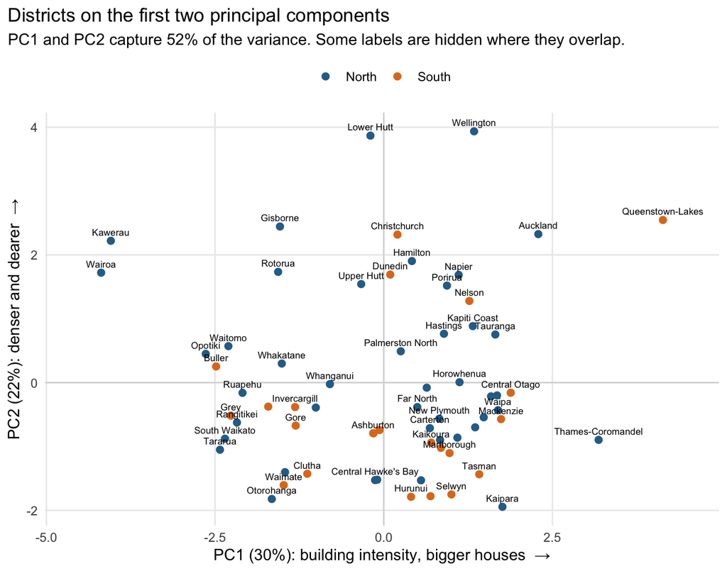

```r
pca_df <- as_tibble(pca$x[, 1:2]) |> mutate(name = rownames(X), island = tf$island, is_city = tf$is_city)
p_pca <- ggplot(pca_df, aes(PC1, PC2)) +
  geom_hline(yintercept = 0, colour = "grey85") + geom_vline(xintercept = 0, colour = "grey85") +
  geom_point(aes(colour = island), size = 2) +
  geom_text(aes(label = name), size = 2.3, vjust = -0.8, check_overlap = TRUE) +
  scale_colour_manual(values = c(North = "#2a6f97", South = "#e07a1f")) +
  scale_x_continuous(expand = expansion(mult = 0.1)) +
  labs(title = "Districts on the first two principal components",
       subtitle = sprintf("PC1 and PC2 capture %.0f%% of the variance. Some labels are hidden where they overlap.",
                          100 * pca_var$cumulative[2]),
       x = sprintf("PC1 (%.0f%%): building intensity, bigger houses  →", 100 * pca_var$variance_share[1]),
       y = sprintf("PC2 (%.0f%%): denser and dearer  →", 100 * pca_var$variance_share[2]), colour = NULL) +
  theme(legend.position = "top")
save_fig(p_pca, "fig03_pca_districts", dir = paths$fig_rq2, height = 5.5, width = 8)
```

**Observation.**

- **PC1** (about 30% of the variance) contrasts districts that build a lot for their population, with bigger houses and more retirement units, against districts with slow, volatile building and a larger non-residential share. It reads as “growing residential market vs slow provincial economy”.
- **PC2** (about 22%) is mainly apartments, townhouses and cost. It separates the dense, dear urban markets from the rest.
- Together they capture only about half of the variance. The other half is spread over several smaller directions, so no single picture shows everything.
- The points form one broad cloud rather than clearly separated groups. The dense urban districts (Wellington, Lower Hutt, Auckland) sit at the top, Queenstown-Lakes far to the right, and small slow-building districts such as Kawerau and Wairoa far to the left. That warns us that any clusters will divide a continuum rather than find natural, well-separated types. Step 2 measures this formally.

# 7 Save

```r
features_out <- list(
  raw          = feat,                 # natural units, all features, for describing clusters
  transformed  = tf,                   # after square-root and log transforms
  cluster_vars = cluster_vars,         # the nine features used for clustering
  window       = paste(min(win$yq), "to", max(win$yq)),
  notes        = "Chatham Islands excluded; house_share and alt_share dropped (VIF)")
saveRDS(features_out, file.path(paths$processed, "rq2_district_features.rds"))
write_csv(feat, file.path(paths$processed, "rq2_district_features.csv"))
list.files(paths$processed, pattern = "rq2")
```

```
## [1] "rq2_district_features.csv" "rq2_district_features.rds"
```

# 8 Summary of decisions

| # | Decision | Reason |
| --- | --- | --- |
| 1 | One row per district; 66 districts (Chatham Islands out) | RQ2 is about markets, not quarters; 34 dwellings in ten years is too few |
| 2 | Window 2016Q3–2026Q2; growth = second vs first five years; volatility over 2006–2025 | Recent but long enough to be stable; volatility needs a full cycle |
| 3 | Size left out of the clustering, used to describe clusters | Otherwise clusters would just rank districts by size |
| 4 | Square root for shares, log for intensity and volatility | Reduce skew so single districts don’t form their own clusters |
| 5 | Standardise all features | Equal weight in the distance regardless of units |
| 6 | Drop `house_share` (VIF infinite) and `alt_share` (VIF ≈ 7) | Avoid counting the same information twice |
| 7 | Nine clustering features, all VIF < 2.5 | Type mix (3), intensity, growth, volatility, cost, house size, non-residential share |

**Next (Step 2):** cluster the 66 districts with k-means and hierarchical clustering, choose the number of clusters, compare the two methods, and describe the clusters.

# 9 Appendix: helper functions

This notebook uses helper functions from `R/utils_data.R` and `R/utils_cluster.R`, printed here so the document is complete on its own.

```r
# =============================================================================
# R/utils_data.R
# Shared helpers for reading and reshaping Stats NZ data.
# Source this from any Rmd after the project root has been set:
#   source(file.path(proj_root, "R", "utils_data.R"))
# =============================================================================

suppressPackageStartupMessages({
  library(data.table)
  library(tidyverse)
})

# ---- Paths (all relative to the project root) -------------------------------
paths <- list(
  raw_extracted = "data/raw/extracted",
  raw_cgpi      = "data/raw/external/cgpi",
  reference     = "data/reference",
  processed     = "data/processed",
  fig_rq1       = "outputs/figures/rq1",
  tab_rq1       = "outputs/tables/rq1",
  fig_rq2       = "outputs/figures/rq2",
  tab_rq2       = "outputs/tables/rq2"
)

# ---- Reading Stats NZ "Infoshare" long-format CSVs --------------------------
# Every Infoshare file has one row per (series x period). We read only the
# columns that carry information and give them short working names.
#
# Notes
# * `Period` MUST be read as text: as a number, "2025.10" becomes 2025.1,
#   which is indistinguishable from January.
# * integer64 is turned off so that large dollar values come back as doubles
#   (integer64 silently overflows on division).
read_infoshare <- function(file,
                           dir = paths$raw_extracted,
                           keep_status = FALSE) {
  cols <- c("Series_reference", "Period", "Data_value",
            "Series_title_1", "Series_title_2",
            "Series_title_3", "Series_title_4", "Series_title_5")
  if (keep_status) cols <- c(cols, "Status")

  dt <- fread(file.path(dir, file),
              select      = cols,
              colClasses  = list(character = "Period"),
              integer64   = "double",
              na.strings  = c("", "NA"),
              showProgress = FALSE)

  as_tibble(dt) |>
    rename(series  = Series_reference,
           period  = Period,
           value   = Data_value,
           area    = Series_title_1,
           btype   = Series_title_2,
           work    = Series_title_3,
           measure = Series_title_4,
           adjust  = Series_title_5)   # Actual / Seasonally adjusted / Trend (regional files only)
}

# ---- Period helpers ----------------------------------------------------------
# "YYYY.MM" -> integer year / month / calendar quarter
period_year    <- function(p) as.integer(substr(p, 1, 4))
period_month   <- function(p) as.integer(substr(p, 6, 7))
month_quarter  <- function(m) (m - 1L) %/% 3L + 1L

# Label like "2019Q3"
yq_label <- function(year, quarter) paste0(year, "Q", quarter)

# Sequential quarter index (1990Q1 = 1) - handy as a numeric time trend
yq_index <- function(year, quarter) (year - 1990L) * 4L + quarter

# ---- GST ---------------------------------------------------------------------
# Consent values are GST-inclusive. GST was 12.5% from 1 Jul 1989 to
# 30 Sep 2010 and 15% from 1 Oct 2010. Every month in our data is >= 1990,
# so only these two rates apply. Quarter boundaries line up with the change
# (2010Q4 starts on 1 Oct 2010), so a quarter-level rule is exact.
gst_rate <- function(year, quarter) {
  if_else(yq_index(year, quarter) >= yq_index(2010L, 4L), 0.15, 0.125)
}

# ---- Small display helpers ---------------------------------------------------
fmt_int <- function(x) format(round(x), big.mark = ",", scientific = FALSE)
fmt_dol <- function(x) paste0("$", fmt_int(x))
fmt_pct <- function(x, d = 1) paste0(format(round(100 * x, d), nsmall = d), "%")

# ---- Figures -----------------------------------------------------------------
theme_set(theme_minimal(base_size = 11) +
            theme(plot.title.position = "plot",
                  panel.grid.minor = element_blank()))

# Save a ggplot as PNG (for the report) and return it (so it also shows in the Rmd)
save_fig <- function(p, name, dir = paths$fig_rq1, width = 7, height = 4.2) {
  dir.create(dir, recursive = TRUE, showWarnings = FALSE)
  ggsave(file.path(dir, paste0(name, ".png")), p,
         width = width, height = height, dpi = 200, bg = "white")
  p
}

# Save a table as CSV (for the report) and return it
save_tab <- function(df, name, dir = paths$tab_rq1) {
  dir.create(dir, recursive = TRUE, showWarnings = FALSE)
  write_csv(df, file.path(dir, paste0(name, ".csv")))
  df
}
```

```r
# =============================================================================
# R/utils_cluster.R
# Shared helpers for clustering (RQ2). Source AFTER utils_data.R:
#   source(file.path(proj_root, "R", "utils_data.R"))
#   source(file.path(proj_root, "R", "utils_cluster.R"))
# Needs the 'cluster' package (installed with R).
# =============================================================================

paths$models_rq2 <- "outputs/models/rq2"

# ---- Variance inflation factor ----------------------------------------------
# VIF_j = 1 / (1 - R2_j), where R2_j comes from regressing feature j on all the
# other features. 1 = unrelated to the others; above about 5 = largely repeated
# by the others. Returns Inf when a feature is an exact combination of others.
vif_table <- function(df) {
  vars <- names(df)
  tibble(feature = vars,
         vif = map_dbl(vars, function(v) {
           r2 <- summary(lm(reformulate(setdiff(vars, v), response = v), data = df))$r.squared
           if (r2 > 1 - 1e-10) Inf else 1 / (1 - r2)
         }))
}

# ---- Adjusted Rand index -----------------------------------------------------
# Agreement between two partitions of the same items, corrected for chance:
# 1 = identical (labels may be numbered differently), 0 = no better than random.
adjusted_rand <- function(a, b) {
  tab <- table(a, b)
  n   <- sum(tab)
  sum_ij <- sum(choose(tab, 2))
  sum_a  <- sum(choose(rowSums(tab), 2))
  sum_b  <- sum(choose(colSums(tab), 2))
  expected <- sum_a * sum_b / choose(n, 2)
  (sum_ij - expected) / ((sum_a + sum_b) / 2 - expected)
}

# ---- Calinski-Harabasz index --------------------------------------------------
# (between-cluster variance / (k - 1)) / (within-cluster variance / (n - k)).
# Higher = tighter, better separated clusters. Same idea as an ANOVA F ratio.
calinski_harabasz <- function(X, cl) {
  X <- as.matrix(X); k <- length(unique(cl)); n <- nrow(X)
  total  <- sum(scale(X, scale = FALSE)^2)
  within <- sum(sapply(unique(cl), function(g) sum(scale(X[cl == g, , drop = FALSE], scale = FALSE)^2)))
  ((total - within) / (k - 1)) / (within / (n - k))
}

# ---- Mean silhouette width -----------------------------------------------------
mean_silhouette <- function(cl, D) mean(cluster::silhouette(cl, D)[, "sil_width"])

# ---- Bootstrap stability -------------------------------------------------------
# How reproducible is a clustering? Repeat B times: draw a bootstrap sample of
# the rows, re-cluster it, and compare with the clustering of the full data on
# the rows that were drawn (adjusted Rand index). Average over the B repeats.
#   cluster_fun(X) must return a vector of cluster labels for the rows of X.
boot_stability <- function(X, cluster_fun, B = 100, seed = 462) {
  set.seed(seed)
  full <- cluster_fun(X)
  map_dbl(seq_len(B), function(b) {
    rows <- sort(unique(sample(nrow(X), replace = TRUE)))
    adjusted_rand(full[rows], cluster_fun(X[rows, , drop = FALSE]))
  })
}

# ---- k-means and Ward wrappers with fixed settings ----------------------------
kmeans_labels <- function(X, k, nstart = 50) kmeans(X, centers = k, nstart = nstart, iter.max = 100)$cluster
ward_labels   <- function(X, k) cutree(hclust(dist(X), method = "ward.D2"), k = k)

# ---- Relabel clusters by size --------------------------------------------------
# k-means numbers clusters arbitrarily (and differently with another seed).
# Renumber so cluster 1 is the largest, which keeps tables and colours stable.
relabel_by_size <- function(cl) {
  ord <- names(sort(table(cl), decreasing = TRUE))
  as.integer(factor(cl, levels = ord))
}
```